# `GeoMakie.GeoAxis` and coordinate reference systems

Author

Jeet Sukumaran

## 1 Geospatial data coordinate reference systems

**Definition:** Coordinate reference system (CRS)**

A coordinate reference system (CRS) defines how spatial coordinates correspond to positions on the Earth, specifying the datum, coordinate system, and units; when projected, it also includes a map projection from the ellipsoid to a plane.

Geospatial data is typically stored using a **coordinate reference system (CRS)**. A CRS specifies how positions are described (e.g. longitude and latitude in degrees) and what those coordinates mean relative to the Earth.

## 2 Plotting geospatial data with standard `Axis`

The GeoMakie package provides a dataset of the world coastlines represented as strings of line segments. This coastline data is returned by the `GeoMakie.coastlines()` function, and is given in **geographic coordinates** (longitude, latitude). These *can* be plotted onto the default Cartesian planar coordinate axes using the `line` function:

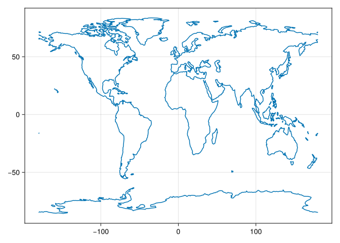

```julia
using GeoMakie, CairoMakie
coasts = GeoMakie.coastlines()
fig = Figure()
ax = Axis(fig[1,1])
lines!(ax, coasts)
fig
```

However, the geospatial data may not always be represented correctly in the Cartesian metric plane, as the coordinates underlying the line segments are encoded using a specific spatial or coordinate reference system that needs to be mapped to points in the linear Cartesian coordinates of the plotting system.

A standard `Axis` treats coordinates as points in a flat Cartesian plane, with orthogonal axes and linear scaling along each dimension. It will not interpret geospatial data coordiantes correctly as locations on a curved surface (such as a sphere or ellipsoid), nor does it account for geodetic structure (how positions relate to the Earth’s shape) or map projection (how the curved surface is flattened onto a plane). As a result, distances are not preserved, shapes may appear distorted, and the result is not a proper map.

This can be especially problematic when combining data from different coordinate reference systems, in which case any results would be probably be invalid even if the analysis could be run without a software error in the first place.

## 3 Plotting geospatial data with standard `GeoAxis`

The `GeoAxis` object addresses this by applying a map *projection* on data plotted in it. This takes coordinates representing positions on the Earth (e.g. longitude and latitude) and transforms them into coordinates on a linearly-scaled flat Euclidean space with orthogonal dimensions, while maintaining selected important geometrical characteristics and spatial relationships.

The `GeoMakie.GeoAxis` interprets any coordinates passed to it as coordinates in a particular CRS (which can be specified as a PROJ-string using the `source` keyword argument of its constructor function, and *projects* (converts) these to points in the linear Cartesian system, also specified as a PROJ-string, but using the `dest` keyword argument of the function. By default, these are `"+proj=longlat +datum=WGS84"` and `"+proj=merc +datum=WGS84"`, respectively, which specify the source as geographic coordinates (longitude and latitude on the WGS84 Earth model) and the projection as the Mercator projection.

```julia
using GeoMakie, CairoMakie
fig = Figure()
ax = GeoAxis(
  fig[1, 1],
  source = "+proj=longlat +datum=WGS84",
  dest   = "+proj=merc +datum=WGS84"
)
lines!(ax, GeoMakie.coastlines())
fig
```

[output not shown]

Back to top